# Hogan Sample Locations

# Pro Tips

Anything in red is a hyperlink that will either take you to the relevant location in this R Notebook .html file, or will link to an external reference (i.e. a publication we cite). If you just want to see the text and figures and **do not** want to see any of the `code` used to generate this R Notebook, click on the grey box in the upper right corner that says “Code” and select “Hide All Code”. Happy data exploring!

# Introduction

The purpose of these analyses is to relate reproductive success (RS) with spatial information from fish sampling areas (new information), origin, date, sex, and length. We associate these variables using generalized linear models (GLM’s).

**Note** that we are only doing these analyses for the Hogan even-year lineage (2014-2016) because there are not enough parent-offspring assignments from the odd lineage (2013-2015) to draw robust conclusions. Also **note that Hogan is a short stream (~30m)** and we assume that the entire stream was sampled each day.

Our prior is that there may be spatial separation between hatchery- and natural-origin Pink Salmon and that this separation may help account for observed differences in RS. Spatial separation in spawning location has been observed in farmed- versus wild- Atlantic salmon, with farmed salmon more often found upriver of wild salmon (see [Moe et al. 2016](https://www.int-res.com/abstracts/aei/v8/p77-88/); [Okland et al. 1995](https://onlinelibrary.wiley.com/doi/abs/10.1111/j.1095-8649.1995.tb05942.x); [Thorstad et al. 1998](https://onlinelibrary.wiley.com/doi/abs/10.1046/j.1365-2109.1998.00218.x)). In contrast, wild Chinook from the Wenatchee River (WA) were found upstream of hatchery fish and had higher RS (see [Williamson et al. 2010](https://www.nrcresearchpress.com/doi/abs/10.1139/F10-099)). Additionally, spawning location may be influenced by return time if late-returning females have to choose less desirable locations (see [Fleming and Reynolds 2003](https://onlinelibrary.wiley.com/doi/pdf/10.1046/j.1365-2656.2003.00752.x)).

To test this spatial-separation hypothesis, we obtained sample location information from the contractor’s Finsight database, which included both processing area number and GPS coordinates [link]. Because processing areas overlapped and were inconsistent among years, we decided we couldn’t use this variable as a proxy for sample location. Instead, we used an R script developed by Pete Rand at PWSSC that allowed us to convert GPS coordinates to distance from the mouth of the stream [link]. We did this transformation and then combined this new variable with origin, date, and length from our RS analyses. We did exploratory plotting to examine relationships among RS, date, length, stream distance, and sex and tested for multicollinearity among our variables [link]. Following [Bernston et al. 2011](https://afspubs.onlinelibrary.wiley.com/doi/pdf/10.1080/00028487.2011.584489), [Ford et al. 2012](https://onlinelibrary.wiley.com/doi/full/10.1111/j.1755-263X.2012.00261.x), and [Janowitz-Koch et al. 2018](https://onlinelibrary.wiley.com/doi/full/10.1111/eva.12725), we used GLM’s to evaluate relationships among RS, stream distance, length, origin and run timing separately for each sex [link].

# Read in, format, and filter data

Spatial data are saved in finsight in two ways: sample processing area and GPS coordinates.

```r
finsight_hogan <- read_csv("finsight_hogan.csv")

finsight_hogan$SurveyDate <- as.Date(finsight_hogan$SurveyDate, "%m/%d/%Y")

finsight_hogan <- finsight_hogan %>%
  mutate(year = as.numeric(format(SurveyDate, format = "%Y")),
         month = as.numeric(format(SurveyDate, format = "%m")),
         day = as.numeric(format(SurveyDate, format = "%d")))

finsight_hogan <- finsight_hogan %>%
  mutate(Longitude = -abs(Longitude))

finsight_hogan_filtered <- finsight_hogan %>%
  filter(Latitude > 60.207 & Longitude < -147.758)

finsight_hogan_filtered$ProcessingAreaNum <- as.factor(finsight_hogan_filtered$ProcessingAreaNum)
```

# Plot processing areas

Below we plot “processing areas” by year. It appears that processing areas changed by day and year.

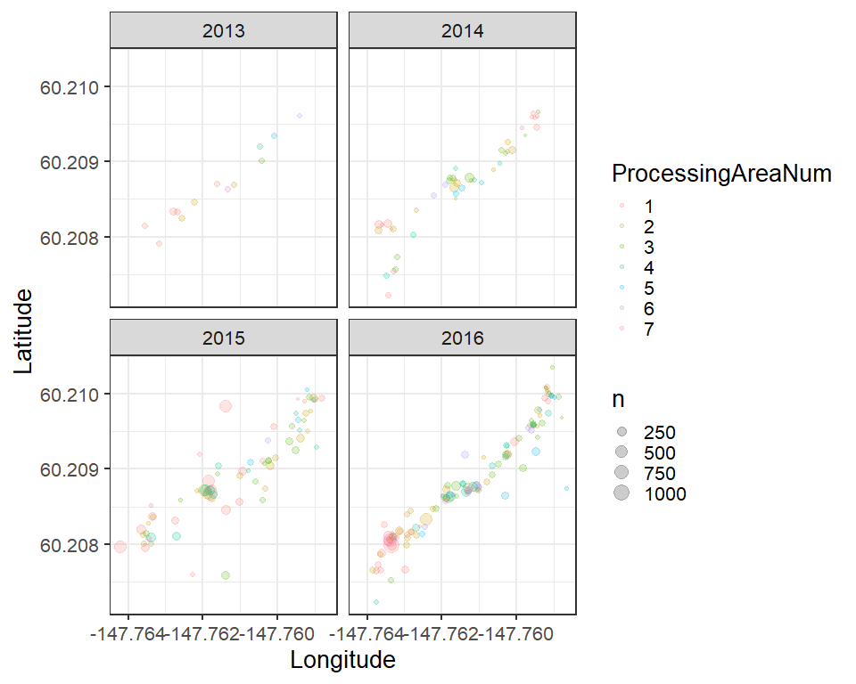

```r
finsight_hogan_filtered %>%
  count(year, ProcessingAreaNum, Longitude, Latitude) %>%
  ggplot(aes(x = Longitude, y = Latitude, color = ProcessingAreaNum, size = n)) +
  geom_point(alpha = 0.2) +
  theme_bw(base_size = 20) +
  facet_wrap(~ year)
```

```r
finsight_hogan %>%
  count(year, ProcessingAreaNum, Longitude, Latitude)
```

| year | ProcessingAreaNum | Longitude | Latitude | n |
| --- | --- | --- | --- | --- |
| 2013 | 1 | -147.7636 | 60.20815 | 58 |
| 2013 | 1 | -147.7632 | 60.20792 | 38 |
| 2013 | 1 | -147.7628 | 60.20834 | 144 |
| 2013 | 1 | -147.7627 | 60.20832 | 71 |
| 2013 | 1 | -147.7616 | 60.20871 | 48 |
| 2013 | 2 | -147.7625 | 60.20825 | 86 |
| 2013 | 2 | -147.7622 | 60.20846 | 96 |
| 2013 | 2 | -147.7612 | 60.20870 | 48 |
| 2013 | 3 | -147.7604 | 60.20901 | 48 |
| 2013 | 4 | -147.7605 | 60.20921 | 48 |

[output cut: 237 more lines]

Seven processing areas were identified each year of sampling. These plots show the locations of the processing areas, with the size of the dot representing the number of individuals sampled. We plotted these locations to determine whether we could use this variable as a proxy for sample location. However, these plots reveal that processing areas are not discrete (they overlap) and that their locations are not consistent across years.

# Convert coordinates to distance from stream mouth

Ultimately, we tried two different methods to convert GPS points to stream distance. Intially we used some R code from Pete Rand to calculate a linear distance for each point from the lowest stream point. However, this method did not account for the sinuosity of streams, so we adopted a more rigorous method using GIS data and the R package *riverdist*. Chase Jalbert used satellite imagery to delineate stream tracks and convert them in to GIS shapefiles. Those stream tracks were then utilized by *riverdist* to “snap” GPS points to the nearest part of the stream track. Once points were snapped, we could calculate the stream distance, determine if they were intertidal vs. upstream, and determine which stream segment they were from.

## Pete Rand’s linear distance method

Because we were not able to use processing area as a proxy for sample location, we used a script from Pete Rand (PWSSC) to transform GPS coordinates into a more meaningful measure: distance from the mouth of the stream. This allowed us to derive a new variable relative to sample location: ‘Distance’ - distance in meters from the mouth of the stream (lowest sampled point).

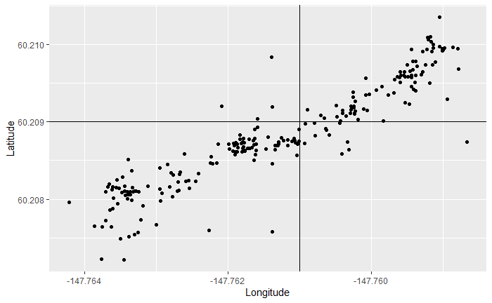

```r
# Calculates the geodesic distance between two points specified by radian latitude/longitude using the
# Haversine formula (hf)
gcd.hf <- function(long1, lat1, long2, lat2) {
  R <- 6371 # Earth mean radius [km]
  delta.long <- (long2 - long1)
  delta.lat <- (lat2 - lat1)
  a <- sin(delta.lat/2)^2 + cos(lat1) * cos(lat2) * sin(delta.long/2)^2
  c <- 2 * asin(min(1, sqrt(a)))
  d = R * c
  return(d) # Distance in km
}

# From Pete Rand on 5/16, high tide extent is estimated to be 60.209, -147.761
finsight_hogan_filtered <- finsight_hogan_filtered %>%
  mutate(Distance = unlist(pmap(list(long1 = min(Longitude), lat1 = min(Latitude), long2 = Longitude, lat2 = Latitude), gcd.hf))) %>%
  mutate(Intertidal = case_when(Distance <= gcd.hf(long1 = min(Longitude), lat1 = min(Latitude), long2 = -147.761, lat2 = 60.209) ~ "Intertidal",
                                Distance > gcd.hf(long1 = min(Longitude), lat1 = min(Latitude), long2 = -147.761, lat2 = 60.209) ~ "Upstream"))

#Plot location of estimated high tide mark
ggplot(finsight_hogan_filtered, aes(x = Longitude, y = Latitude)) +
  geom_point() +
  geom_vline(aes(xintercept = -147.761)) +
  geom_hline(aes(yintercept = 60.209))
```

```r
# A function to convert degrees to radians
# deg2rad <- function(deg) return(deg*pi/180)
```

## *riverdist* package with GIS stream track

```r
(riverdist <- read_csv("../../GIS/R/hogan/hogan_distances.csv") %>%
   mutate(Intertidal = case_when(dist2tide > 0 ~ "Upstream",
                                 dist2tide <= 0 ~ "Intertidal")) %>%
   rename(Distance = mouthdist, Segment = seg))
```

| Segment | vert | snapdist | Sample | Latitude | Longitude | Distance | hitide | dist2tide | Intertidal |
| --- | --- | --- | --- | --- | --- | --- | --- | --- | --- |
| 1 | 412 | 43.410735 | 0000002036_1 | 60.20852 | -147.7634 | 267.99412 | 428.9354 | -160.941268 | Intertidal |
| 1 | 412 | 43.410735 | 0000002036_2 | 60.20852 | -147.7634 | 267.99412 | 428.9354 | -160.941268 | Intertidal |
| 1 | 412 | 43.410735 | 0000002036_3 | 60.20852 | -147.7634 | 267.99412 | 428.9354 | -160.941268 | Intertidal |
| 1 | 412 | 43.410735 | 0000002036_4 | 60.20852 | -147.7634 | 267.99412 | 428.9354 | -160.941268 | Intertidal |
| 1 | 412 | 43.410735 | 0000002036_5 | 60.20852 | -147.7634 | 267.99412 | 428.9354 | -160.941268 | Intertidal |
| 1 | 412 | 43.410735 | 0000002036_6 | 60.20852 | -147.7634 | 267.99412 | 428.9354 | -160.941268 | Intertidal |
| 1 | 412 | 43.410735 | 0000002036_7 | 60.20852 | -147.7634 | 267.99412 | 428.9354 | -160.941268 | Intertidal |
| 1 | 309 | 57.022666 | 0000002038_1 | 60.20920 | -147.7621 | 368.98516 | 428.9354 | -59.950229 | Intertidal |
| 1 | 309 | 57.022666 | 0000002038_10 | 60.20920 | -147.7621 | 368.98516 | 428.9354 | -59.950229 | Intertidal |
| 1 | 309 | 57.022666 | 0000002038_11 | 60.20920 | -147.7621 | 368.98516 | 428.9354 | -59.950229 | Intertidal |

[output cut: 990 more lines]

# Join *riverdist* table with parentage data

We joined spatial data from *riverdist* with parentage data.

```r
paired_14_16_filter_parents <- read_csv("paired_14_16_filter_parents.csv")

riverdist_parentage_hogan <- paired_14_16_filter_parents %>%
  unite("Sample", c("DNA Tray Code", "DNA Tray Well Code"), sep = "_", remove = FALSE) %>%
  left_join(riverdist, by = "Sample") %>%
  mutate(origin = factor(origin, c("Natural", "Hatchery")))  %>%
  mutate(`Sample Date` = ymd(`Sample Date`)) %>%
  filter(is.na(`Length Mm`) | `Length Mm` > 300) %>%
  mutate(Segment = factor(Segment))%>%
  mutate(Success = case_when(n == 0 ~ "Unsuccessful",
                             n > 0 ~ "Successful"))

write_csv(riverdist_parentage_hogan, "riverdist_parentage_hogan.csv")
```

Some quick exploratory animation.

```r
sample_dates <- unique(sort(riverdist_parentage_hogan$`Sample Date`))
my.animation <- riverdist_parentage_hogan %>%
  mutate(grpI = as.numeric(factor(`Sample Date`))) %>%
  ggplot(aes(x = Longitude, y = Latitude, colour = origin, size = n, alpha = 0.05, group = seq_along(`Sample Date`))) +
  coord_equal() +
  geom_jitter() +
  theme_bw() +
  guides(alpha = FALSE) +
  labs(size = "RS", colour = "Parent: Origin") +
  # theme(text = element_text(size = 20)) +
  transition_reveal(grpI) +
  ggtitle("Date: {sample_dates[floor(frame_along)]}")
animate(my.animation, height = 1200, width = 2400, res = 300)
```

[output not shown]

[output cut: 46 more lines]

[output not shown]

Simple plot of RS by parent sample date and distance (both origins and sexes combined)

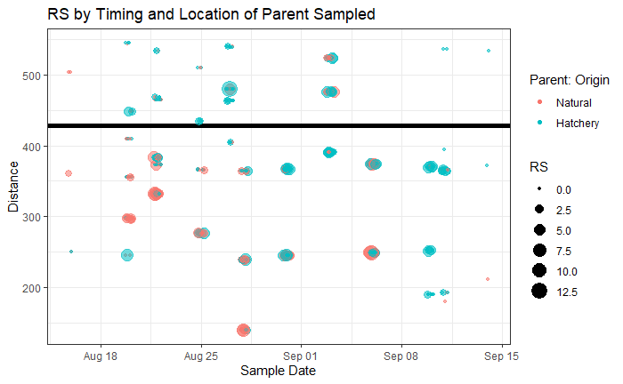

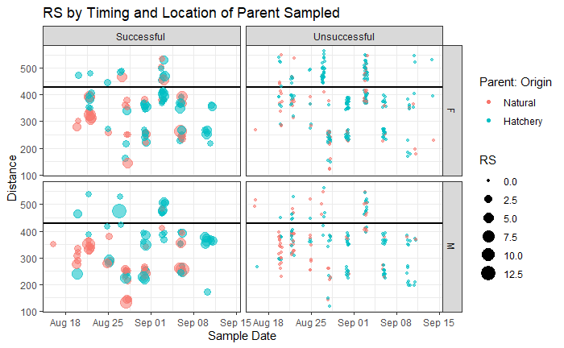

```r
riverdist_parentage_hogan %>%
  ggplot(aes(x = `Sample Date`, y = Distance, size = n, colour = origin, alpha = 0.01)) +
  geom_hline(aes(yintercept = hitide), size = 1) +
  geom_jitter(width = 0.25, height = 25) +
  theme_bw() +
  guides(alpha = FALSE) +
  labs(size = "RS", colour = "Parent: Origin") +
  ggtitle("RS by Timing and Location of Parent Sampled") +
  facet_grid(SEX ~ Success)
```

Look at cross type data! What are the spatio-temporal patterns in matings of different cross types?

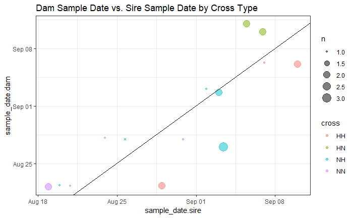

```r
parents_paired_14_16_cross <- read_csv("parents_paired_14_16_cross.csv")
# organize by sire and dam, join riverdist data
parents_paired_14_16_cross_riverdist <- parents_paired_14_16_cross %>%
  count(cross, `Fish ID`, `Fish ID.par1`, `Sample Date`, `Sample Date.par1`, SEX, SEX.par1, `DNA Tray Code`, `DNA Tray Code.par1`, `DNA Tray Well Code`, `DNA Tray Well Code.par1`, origin.par1, origin, `Length Mm.par1`, `Length Mm`) %>%
  rename(`Fish ID.par2` = `Fish ID`,
         `Sample Date.par2` = `Sample Date`,
         SEX.par2 = SEX,
         `DNA Tray Code.par2` = `DNA Tray Code`,
         `DNA Tray Well Code.par2` = `DNA Tray Well Code`,
         origin.par2 = origin,
         `Length Mm.par2` = `Length Mm`) %>%
  unite(Sample.par1, c("DNA Tray Code.par1", "DNA Tray Well Code.par1"), sep = "_", remove = TRUE) %>%
  unite(Sample.par2, c("DNA Tray Code.par2", "DNA Tray Well Code.par2"), sep = "_", remove = TRUE) %>%
  left_join(riverdist, by = c("Sample.par1" = "Sample")) %>%
  left_join(riverdist, by = c("Sample.par2" = "Sample"), suffix = c(".par1", ".par2")) %>%
  mutate(fish_id.sire = case_when(SEX.par1 == "M" ~ `Fish ID.par1`,
                                  TRUE ~ `Fish ID.par2`)) %>%
  mutate(fish_id.dam = case_when(SEX.par1 == "F" ~ `Fish ID.par1`,
                                  TRUE ~ `Fish ID.par2`)) %>%
  mutate(sample_date.sire = case_when(SEX.par1 == "M" ~ `Sample Date.par1`,
                                  TRUE ~ `Sample Date.par2`)) %>%
  mutate(sample_date.dam = case_when(SEX.par1 == "F" ~ `Sample Date.par1`,
                                  TRUE ~ `Sample Date.par2`)) %>%
  mutate(sex.sire = case_when(SEX.par1 == "M" ~ SEX.par1,
                                  TRUE ~ SEX.par2)) %>%
  mutate(sex.dam = case_when(SEX.par1 == "F" ~ SEX.par1,
                                  TRUE ~ SEX.par2)) %>%
  mutate(origin.sire = case_when(SEX.par1 == "M" ~ origin.par1,
                                  TRUE ~ origin.par2)) %>%
  mutate(origin.dam = case_when(SEX.par1 == "F" ~ origin.par1,
                                  TRUE ~ origin.par2)) %>%
  mutate(distance.sire = case_when(SEX.par1 == "M" ~ Distance.par1,
                                  TRUE ~ Distance.par2)) %>%
  mutate(distance.dam = case_when(SEX.par1 == "F" ~ Distance.par1,
                                  TRUE ~ Distance.par2)) %>%
  mutate(intertidal.sire = case_when(SEX.par1 == "M" ~ Intertidal.par1,
                                  TRUE ~ Intertidal.par2)) %>%
  mutate(intertidal.dam = case_when(SEX.par1 == "F" ~ Intertidal.par1,
                                  TRUE ~ Intertidal.par2)) %>%
  mutate(length.sire = case_when(SEX.par1 == "M" ~ `Length Mm.par1`,
                                  TRUE ~ `Length Mm.par2`)) %>%
  mutate(length.dam = case_when(SEX.par1 == "F" ~ `Length Mm.par1`,
                                  TRUE ~ `Length Mm.par2`)) %>%
  select(cross, n, ends_with(".sire"), ends_with(".dam"))
parents_paired_14_16_cross_riverdist %>%
  ggplot(aes(x = sample_date.sire, y = sample_date.dam)) +
  geom_jitter(aes(colour = cross, size = n), alpha = 0.5) +
  geom_abline(slope = 1) +
  theme_bw() +
  ggtitle("Dam Sample Date vs. Sire Sample Date by Cross Type")
```

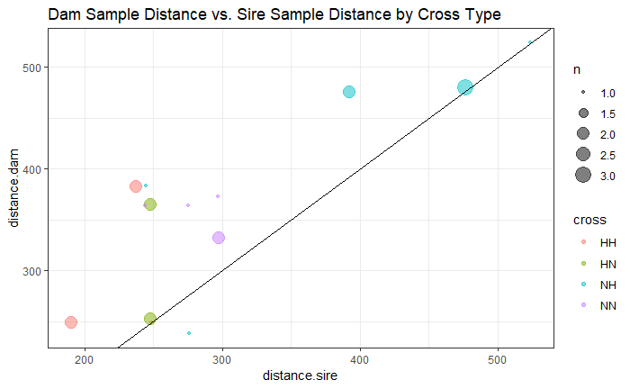

```r
parents_paired_14_16_cross_riverdist %>%
  ggplot(aes(x = distance.sire, y = distance.dam), alpha = 0.05) +
  geom_jitter(aes(colour = cross, size = n), alpha = 0.5) +
  geom_abline(slope = 1)+
  theme_bw() +
  ggtitle("Dam Sample Distance vs. Sire Sample Distance by Cross Type")
```

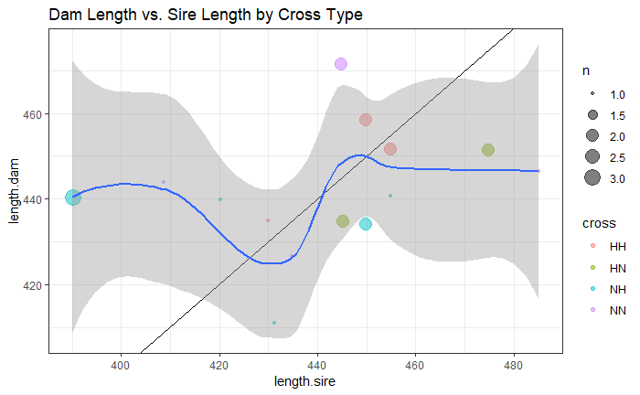

```r
parents_paired_14_16_cross_riverdist %>%
  filter(length.sire > 300 & length.dam > 300) %>%
  ggplot(aes(x = length.sire, y = length.dam), alpha = 0.05) +
  geom_jitter(aes(colour = cross, size = n), alpha = 0.5) +
  geom_abline(slope = 1)+
  geom_smooth() +
  theme_bw() +
  ggtitle("Dam Length vs. Sire Length by Cross Type")
```

# Check for multi-collinearity

Before modeling RS, we checked for multi-collinearity among variables because we assumed that there would be some degree of non-independence. *Note* that these plots exclude individuals with missing data.

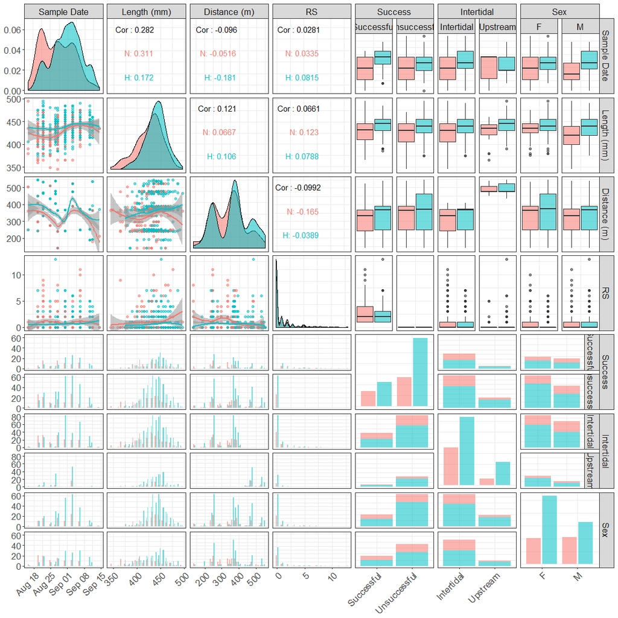

```r
reduced <- riverdist_parentage_hogan %>%
  rename(RS = n, Sex = SEX) %>%
  mutate(Origin = case_when(origin == "Natural" ~ "N",
                            origin == "Hatchery" ~ "H")) %>%
  mutate(Origin = factor(Origin, levels = c("N", "H"))) %>%
  select(`Sample Date`, Sex, `Length Mm`, Origin, RS, Success, Intertidal, Distance) %>%
  drop_na()
ggpairs(reduced,
        mapping = aes(color = Origin, alpha = 0.5),
        columns = c("Sample Date", "Length Mm", "Distance","RS", "Success", "Intertidal", "Sex"),
        columnLabels = c("Sample Date", "Length (mm)", "Distance (m)", "RS", "Success", "Intertidal", "Sex"),
        progress = FALSE,
        lower = list(continuous = "smooth_loess", combo = wrap(ggally_facethist, position = "dodge2")),
        upper = list(continuous = wrap("cor", size = 4, hjust = 0.8), combo = "box"),
        diag = list(discrete = wrap(ggally_barDiag, position = "dodge2"))
        ) +
  theme_bw() +
  theme(axis.text.x  = element_text(angle = 45, hjust = 1),
        text = element_text(size = 16))
```

Overall, correlations among variables are pretty weak. Weak positive correlations were found between length and date (r = 0.28), RS and date (r = 0.03), distance and length (r = 0.12), and RS and length (r = 0.07). Weak negative correlations were found between distance and date (r = -0.10) and RS and distance (r = -0.10).

# Individual plots

## Plot sample location by sample date for each sex

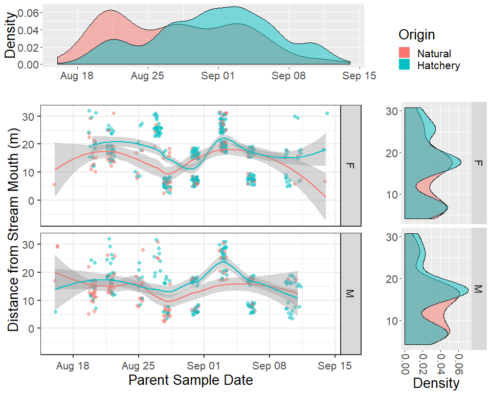

```r
pMain <- ggplot(finsight_parentage_hogan, aes(x = `Sample Date`, y = Distance, color = origin)) +
  geom_jitter(height = 2, size = 2, alpha = 0.5) +
  geom_smooth() +
  facet_grid(Sex ~ .) +
  labs(colour = "Parent: Origin",
       shape = "Parent: Sex", size = "Reproductive Success") +
  xlab("Parent Sample Date") +
  ylab("Distance from Stream Mouth (m)") +
  theme_bw(base_size = 20) +
  theme(legend.position = "none")
pTop <- ggplot(finsight_parentage_hogan, aes(x = `Sample Date`, fill = origin)) +
  # geom_histogram(position = "dodge2") +
  geom_density(alpha = 0.5) +
  theme(legend.position = "none", text = element_text(size = 20)) +
  ylab("Density") +
  xlab("")
pRight <- ggplot(finsight_parentage_hogan, aes(x = Distance, fill = origin)) +
  # geom_histogram(position = "dodge2") +
  geom_density(alpha = 0.5) +
  theme(legend.position = "none", text = element_text(size = 20)) +
  ylab("Density") +
  xlab("") +
  theme(axis.text.x = element_text(angle = 270, vjust = 0.3, hjust = 1)) +
  coord_flip() +
  facet_grid(SEX ~ . )
g_legend <- function(a.gplot){
    tmp <- ggplot_gtable(ggplot_build(a.gplot))
    leg <- which(sapply(tmp$grobs, function(x) x$name) == "guide-box")
    legend <- tmp$grobs[[leg]]
    legend
}
pEmpty <- ggplot(finsight_parentage_hogan, aes(x = `Sample Date`, fill = origin)) +
  geom_histogram(position = "dodge2") +
  theme_bw(base_size = 20) +
  labs(fill = "Origin")
grid.arrange(pTop, g_legend(pEmpty), pMain, pRight, ncol = 2, nrow = 2, widths = c(3,1), heights = c(1,3))
```

```r
# ggExtra::ggMarginal(pMain, type = "histogram")
```

## Plot RS by distance

For a better look at the relationship between RS and distance, we plotted RS by distance separately by sex.

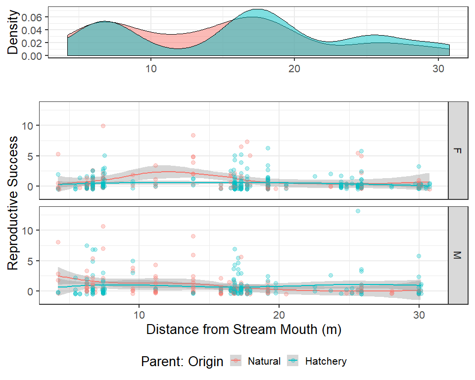

```r
pMain <- finsight_parentage_hogan %>%
  ggplot(aes(x = Distance, y = n, color = origin)) +
  geom_smooth() +
  geom_jitter(height = 0.5, alpha = 0.3, size = 3) +
  facet_grid(Sex ~ .) +
  labs(colour = "Parent: Origin",
       shape = "Parent: Sex") +
  xlab("Distance from Stream Mouth (m)") +
  ylab("Reproductive Success") +
  theme_bw(base_size = 20) +
  theme(legend.position = "bottom")
pTop <- ggplot(finsight_parentage_hogan, aes(x = Distance, fill = origin)) +
  theme_bw(base_size = 20) +
  geom_density(alpha = 0.5) +
  ylab("Density") +
  xlab("") +
  # geom_histogram(aes(fill = origin), position = "dodge2") +
  theme(legend.position = "none")
grid.arrange(pTop, pMain, ncol = 1, nrow = 2, heights = c(1, 3))
```

These plots show RS (number of offspring) by distance from stream mouth (m), faceted by sex. For both sexes, natural-origin individuals had higher RS closer to the stream mouth than hatchery-origin individuals. Hatchery-origin individuals tended to have consistent RS throught the stream and were more commonly sampled further upstream than natural-origin individuals. Gray bars represent loess smoothing CI’s. Note that plots are jittered and points are partially transparent to prevent overplotting.

## Plot length by distance

Are fish separating within the stream based on body size?

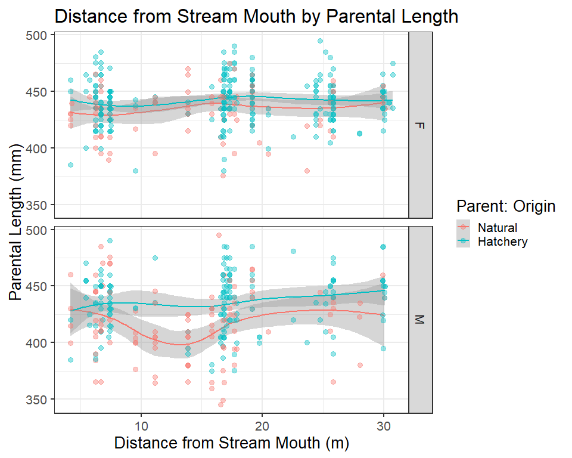

```r
finsight_parentage_hogan %>%
  ggplot(aes(x = Distance, y = `Length Mm`, color = origin)) +
  geom_smooth() +
  geom_jitter(height = 0.5, alpha = 0.4, size = 3) +
  facet_grid(Sex ~ .) +
  labs(title = "Distance from Stream Mouth by Parental Length",
       colour = "Parent: Origin",
       shape = "Parent: Sex") +
  xlab("Distance from Stream Mouth (m)") +
  ylab("Parental Length (mm)") +
  theme_bw(base_size = 20)
```

These plots show the relationship between parent length (mm) and distance from the stream mouth (m), faceted by sex. Overall, for both sexes, there were large size ranges at each sampling location. Gray bars represent loess smoothing and points are jittered to prevent overplotting.

## Plot RS by date, sex, and location

These plots explore the relationship between RS and parent sample date, location (intertidal vs. upstream), and sex. This is an attempt to visualize how spatio-temporal dynamics affect RS.

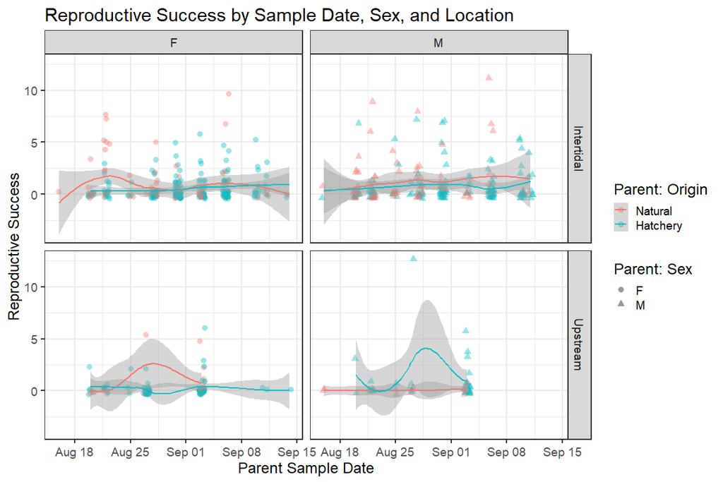

```r
# finsight_parentage_hogan_sw <- finsight_parentage_hogan %>%
#   dplyr::mutate(statweek = dplyr::case_when(
#     `Sample Date` == "2014-08-16" ~ "33",
#     `Sample Date` == "2014-08-20" | `Sample Date` == "2014-08-22" ~ "34",
#     `Sample Date` >= "2014-08-25" & `Sample Date` <= "2014-08-31" ~ "35",
#     `Sample Date` >= "2014-09-03" & `Sample Date` <= "2014-09-06" ~ "36",
#     `Sample Date` >= "2014-09-10" & `Sample Date` <= "2014-09-14" ~ "37"))
#
# finsight_parentage_hogan_sw %>%
#   ggplot(aes(x = Distance, y = n, color = origin, shape = SEX)) +
#   geom_jitter(alpha = 0.5) +
#   geom_smooth() +
#   facet_grid(statweek ~ SEX) +
#   labs(title = "Reproductive Success by Parental Sample Location",
#        colour = "Parent: Origin",
#        shape = "Parent: Sex") +
#   xlab("Distance from Stream Mouth (m)") +
#   ylab("Reproductive Success") +
#   theme_bw()
finsight_parentage_hogan %>%
  ggplot(aes(x = `Sample Date`, y = n, color = origin, shape = SEX)) +
  geom_jitter(alpha = 0.4, size = 3) +
  geom_smooth() +
  facet_grid(Intertidal ~ SEX) +
  labs(title = "Reproductive Success by Sample Date, Sex, and Location",
       colour = "Parent: Origin",
       shape = "Parent: Sex") +
  xlab("Parent Sample Date") +
  ylab("Reproductive Success") +
  theme_bw(base_size = 18)
```

This plot shows RS (number of offspring) by parent sample date, faceted by sex and location (intertidal vs. upstream). Natural-origin fish of both sexes are more abundant earlier in the season than later. Fish sampled in the intertidal appear to have higher average RS than those sampled upstream - this is particularly true for natural-origin. While there are some patterns for upstream, note that the sample sizes are smaller (and hence the loess CIs are wider). Gray bars represent loess smoothing CIs and points are jittered and partially transparent to reduce overplotting.

# Use GLM’s to associate RS with sample location, date, origin, and length by sex

We used a negative binomial distribution model and log-linked function to evaluation associations between RS and origin, length, sample date, and location separately for females and males. We ran 24 models for each sex, identified statistically significant variables, and selected the best model based on AIC and model complexity. We avoided overly-complex models by only including first order interactions with origin. Since we have two variables for location (Intertidal[categorical] or Distance[continuous]), only one was included at a time in any model.

## Female

### Negative binomial GLMs

```r
Female.even <-
  finsight_parentage_hogan %>%
  filter(SEX == "F")
RS.glm.F.full <- glm.nb(n ~ `Sample Date` + `Length Mm` + origin + Distance, data = Female.even, link = log)
RS.glm.F.2 <- glm.nb(n ~ `Sample Date` + `Length Mm` + origin, data = Female.even, link = log)
RS.glm.F.3 <- glm.nb(n ~ `Length Mm` + origin, data = Female.even, link = log)
RS.glm.F.4 <- glm.nb(n ~ origin, data = Female.even, link = log)
RS.glm.F.5 <- glm.nb(n ~ `Length Mm`, data = Female.even, link = log)
RS.glm.F.6 <- glm.nb(n ~ `Sample Date`, data = Female.even, link = log)
RS.glm.F.7 <- glm.nb(n ~ Distance, data = Female.even, link = log)
RS.glm.F.8 <- glm.nb(n ~ `Sample Date` + `Length Mm` + Distance, data = Female.even, link = log)
RS.glm.F.9 <- glm.nb(n ~ `Length Mm` + Distance, data = Female.even, link = log)
RS.glm.F.10 <- glm.nb(n ~ `Sample Date` + origin, data = Female.even, link = log)
RS.glm.F.11 <- glm.nb(n ~ `Sample Date` + Distance, data = Female.even, link = log)
RS.glm.F.12 <- glm.nb(n ~ `Sample Date` + Distance + origin, data = Female.even, link = log)
RS.glm.F.13 <- glm.nb(n ~ Distance + origin, data = Female.even, link = log)
RS.glm.F.14 <- glm.nb(n ~ Distance * origin, data = Female.even, link = log)
RS.glm.F.15 <- glm.nb(n ~ `Sample Date` * origin, data = Female.even, link = log)
RS.glm.F.16 <- glm.nb(n ~ `Length Mm` * origin, data = Female.even, link = log)
RS.glm.F.17 <- glm.nb(n ~ `Sample Date` + `Length Mm` + origin + Intertidal, data = Female.even, link = log)
RS.glm.F.18 <- glm.nb(n ~ Intertidal, data = Female.even, link = log)
RS.glm.F.19 <- glm.nb(n ~ `Sample Date` + `Length Mm` + Intertidal, data = Female.even, link = log)
RS.glm.F.20 <- glm.nb(n ~ `Length Mm` + Intertidal, data = Female.even, link = log)
RS.glm.F.21 <- glm.nb(n ~ `Sample Date` + Intertidal, data = Female.even, link = log)
RS.glm.F.22 <- glm.nb(n ~ `Sample Date` + Intertidal + origin, data = Female.even, link = log)
RS.glm.F.23 <- glm.nb(n ~ Intertidal + origin, data = Female.even, link = log)
RS.glm.F.24 <- glm.nb(n ~ Intertidal * origin, data = Female.even, link = log)
```

### Extract Akaike Weights

Akaike weights are another way of determining which model has the best fit, by calculating their conditional probabilities.

The model with the highest weight (0.25) included sample date, length, origin, and intertidal. Origin was consistantly associated with RS in all of the top models.

```r
female_model_summary <- bind_rows(
  lapply(c("full", 2:24), function(i) {
    fit <- get(paste0("RS.glm.F.", i))
    summary(fit)$coefficients %>%
      as_tibble(rownames = "variable") %>%
      mutate(name = paste0("RS.glm.F.", i)) %>%
      mutate(model = as.character(fit$call)[2]) %>%
      mutate(AIC = fit$aic) %>%
      mutate(residual_deviance = fit$deviance) %>%
      mutate(residual_df = fit$df.residual) %>%
      mutate(null_deviance = fit$null.deviance) %>%
      mutate(null_df = fit$df.null)
  } )
)
female_aic <- AIC(RS.glm.F.full, RS.glm.F.2, RS.glm.F.3, RS.glm.F.4, RS.glm.F.5, RS.glm.F.6, RS.glm.F.7, RS.glm.F.8, RS.glm.F.9, RS.glm.F.10, RS.glm.F.11, RS.glm.F.12, RS.glm.F.13, RS.glm.F.14, RS.glm.F.15, RS.glm.F.16, RS.glm.F.17, RS.glm.F.18, RS.glm.F.19, RS.glm.F.20, RS.glm.F.21, RS.glm.F.22, RS.glm.F.23, RS.glm.F.24)
female_aic <- female_aic %>%
  mutate(AIC_weight = as.numeric(Weights(female_aic))) %>%
  mutate(name = rownames(female_aic)) %>%
  arrange(AIC) %>%
  mutate(delta_AIC = AIC - min(AIC))
(female_model_summary <- female_model_summary %>%
  left_join(female_aic, by = c("name", "AIC")) %>%
  arrange(AIC)) %>%
  select(name, model, df, AIC, delta_AIC, AIC_weight, variable, Estimate, `Std. Error`, residual_deviance, residual_df, null_deviance, null_df)
```

| name | model | df | AIC | delta_AIC | AIC_weight | variable | Estimate | Std. Error | residual_deviance | residual_df | null_deviance | null_df |
| --- | --- | --- | --- | --- | --- | --- | --- | --- | --- | --- | --- | --- |
| RS.glm.F.17 | n ~ `Sample Date` + `Length Mm` + origin + Intertidal | 6 | 735.0592 | 0.000000 | 0.2455445639 | (Intercept) | -4.298304e+02 | 3.431038e+02 | 236.7809 | 364 | 252.0992 | 368 |
| RS.glm.F.17 | n ~ `Sample Date` + `Length Mm` + origin + Intertidal | 6 | 735.0592 | 0.000000 | 0.2455445639 | `Sample Date` | 2.619216e-02 | 2.104246e-02 | 236.7809 | 364 | 252.0992 | 368 |
| RS.glm.F.17 | n ~ `Sample Date` + `Length Mm` + origin + Intertidal | 6 | 735.0592 | 0.000000 | 0.2455445639 | `Length Mm` | 6.229925e-03 | 6.188341e-03 | 236.7809 | 364 | 252.0992 | 368 |
| RS.glm.F.17 | n ~ `Sample Date` + `Length Mm` + origin + Intertidal | 6 | 735.0592 | 0.000000 | 0.2455445639 | originHatchery | -8.748934e-01 | 2.655763e-01 | 236.7809 | 364 | 252.0992 | 368 |
| RS.glm.F.17 | n ~ `Sample Date` + `Length Mm` + origin + Intertidal | 6 | 735.0592 | 0.000000 | 0.2455445639 | IntertidalUpstream | -5.345437e-01 | 2.986323e-01 | 236.7809 | 364 | 252.0992 | 368 |
| RS.glm.F.2 | n ~ `Sample Date` + `Length Mm` + origin | 5 | 736.2309 | 1.171652 | 0.1366813856 | (Intercept) | -4.944053e+02 | 3.430154e+02 | 236.2989 | 365 | 248.1795 | 368 |
| RS.glm.F.2 | n ~ `Sample Date` + `Length Mm` + origin | 5 | 736.2309 | 1.171652 | 0.1366813856 | `Sample Date` | 3.014376e-02 | 2.103719e-02 | 236.2989 | 365 | 248.1795 | 368 |
| RS.glm.F.2 | n ~ `Sample Date` + `Length Mm` + origin | 5 | 736.2309 | 1.171652 | 0.1366813856 | `Length Mm` | 6.323910e-03 | 6.246667e-03 | 236.2989 | 365 | 248.1795 | 368 |
| RS.glm.F.2 | n ~ `Sample Date` + `Length Mm` + origin | 5 | 736.2309 | 1.171652 | 0.1366813856 | originHatchery | -9.289775e-01 | 2.655724e-01 | 236.2989 | 365 | 248.1795 | 368 |
| RS.glm.F.3 | n ~ `Length Mm` + origin | 4 | 736.2697 | 1.210542 | 0.1340493078 | (Intercept) | -2.370697e+00 | 2.693739e+00 | 236.8338 | 366 | 246.5849 | 368 |

[output cut: 70 more lines]

```r
female_model_summary %>%
  group_by(name) %>%
  summarise(AIC_weight = max(AIC_weight), model = unique(model)) %>%
  arrange(desc(AIC_weight))
```

| name | AIC_weight | model |
| --- | --- | --- |
| RS.glm.F.17 | 0.2455445639 | n ~ `Sample Date` + `Length Mm` + origin + Intertidal |
| RS.glm.F.2 | 0.1366813856 | n ~ `Sample Date` + `Length Mm` + origin |
| RS.glm.F.3 | 0.1340493078 | n ~ `Length Mm` + origin |
| RS.glm.F.full | 0.1051289359 | n ~ `Sample Date` + `Length Mm` + origin + Distance |
| RS.glm.F.23 | 0.0670773141 | n ~ Intertidal + origin |
| RS.glm.F.16 | 0.0548310569 | n ~ `Length Mm` * origin |
| RS.glm.F.15 | 0.0537824987 | n ~ `Sample Date` * origin |
| RS.glm.F.22 | 0.0472712822 | n ~ `Sample Date` + Intertidal + origin |
| RS.glm.F.24 | 0.0271537812 | n ~ Intertidal * origin |
| RS.glm.F.4 | 0.0252972919 | n ~ origin |

[output cut: 14 more lines]

```r
female_model_summary %>%
  select(-`Std. Error`, -`z value`, -`Pr(>|z|)`) %>%
  spread(variable, Estimate, fill = NA)
```

| name | model | AIC | residual_deviance | residual_df | null_deviance | null_df | df | AIC_weight | delta_AIC | (Intercept) | `Length Mm` | `Length Mm`:originHatchery | `Sample Date` | `Sample Date`:originHatchery | Distance | Distance:originHatchery | IntertidalUpstream | IntertidalUpstream:originHatchery | originHatchery |
| --- | --- | --- | --- | --- | --- | --- | --- | --- | --- | --- | --- | --- | --- | --- | --- | --- | --- | --- | --- |
| RS.glm.F.17 | n ~ `Sample Date` + `Length Mm` + origin + Intertidal | 735.0592 | 236.7809 | 364 | 252.0992 | 368 | 6 | 0.2455445639 | 0.000000 | -429.83040887 | 0.006229925 | NA | 0.026192160 | NA | NA | NA | -0.5345437 | NA | -0.8748934 |
| RS.glm.F.2 | n ~ `Sample Date` + `Length Mm` + origin | 736.2309 | 236.2989 | 365 | 248.1795 | 368 | 5 | 0.1366813856 | 1.171652 | -494.40532698 | 0.006323910 | NA | 0.030143758 | NA | NA | NA | NA | NA | -0.9289775 |
| RS.glm.F.3 | n ~ `Length Mm` + origin | 736.2697 | 236.8338 | 366 | 246.5849 | 368 | 4 | 0.1340493078 | 1.210542 | -2.37069745 | 0.005437590 | NA | NA | NA | NA | NA | NA | NA | -0.7940593 |
| RS.glm.F.full | n ~ `Sample Date` + `Length Mm` + origin + Distance | 736.7558 | 236.4160 | 364 | 249.8796 | 368 | 6 | 0.1051289359 | 1.696582 | -436.89918810 | 0.007347586 | NA | 0.026610153 | NA | -0.02153282 | NA | NA | NA | -0.8873618 |
| RS.glm.F.23 | n ~ Intertidal + origin | 737.6545 | 238.1139 | 373 | 250.9846 | 375 | 4 | 0.0670773141 | 2.595265 | 0.07148855 | NA | NA | NA | NA | NA | NA | -0.5928648 | NA | -0.7139874 |
| RS.glm.F.16 | n ~ `Length Mm` * origin | 738.0576 | 236.8508 | 365 | 246.8270 | 368 | 5 | 0.0548310569 | 2.998443 | -4.42797789 | 0.010165494 | -0.00668165 | NA | NA | NA | NA | NA | NA | 2.1273438 |
| RS.glm.F.15 | n ~ `Sample Date` * origin | 738.0963 | 238.6627 | 372 | 253.2529 | 375 | 5 | 0.0537824987 | 3.037061 | 377.47529317 | NA | NA | -0.023144604 | 0.08340505 | NA | NA | NA | NA | -1361.3565168 |
| RS.glm.F.22 | n ~ `Sample Date` + Intertidal + origin | 738.3544 | 237.9182 | 372 | 252.1709 | 375 | 5 | 0.0472712822 | 3.295151 | -392.57268615 | NA | NA | 0.024073058 | NA | NA | NA | -0.5617468 | NA | -0.8138052 |
| RS.glm.F.24 | n ~ Intertidal * origin | 739.4631 | 238.1577 | 372 | 251.2368 | 375 | 5 | 0.0271537812 | 4.403924 | 0.03468556 | NA | NA | NA | NA | NA | NA | -0.3913605 | -0.2844552 | -0.6581528 |
| RS.glm.F.4 | n ~ origin | 739.6048 | 237.5652 | 374 | 246.2129 | 375 | 3 | 0.0252972919 | 4.545562 | -0.02898754 | NA | NA | NA | NA | NA | NA | NA | NA | -0.7448175 |

[output cut: 14 more lines]

```r
write_csv(female_model_summary, "../Hogan/hogan_glm_female_summary.csv")
```

## Male

### Negative binomial GLMs

```r
Male.even <-
  finsight_parentage_hogan %>%
  filter(SEX == "M")
RS.glm.M.full <- glm.nb(n ~ `Sample Date` + `Length Mm` + origin + Distance, data = Male.even, link = log)
RS.glm.M.2 <- glm.nb(n ~ `Sample Date` + `Length Mm` + origin, data = Male.even, link = log)
RS.glm.M.3 <- glm.nb(n ~ `Length Mm` + origin, data = Male.even, link = log)
RS.glm.M.4 <- glm.nb(n ~ origin, data = Male.even, link = log)
RS.glm.M.5 <- glm.nb(n ~ `Length Mm`, data = Male.even, link = log)
RS.glm.M.6 <- glm.nb(n ~ `Sample Date`, data = Male.even, link = log)
RS.glm.M.7 <- glm.nb(n ~ Distance, data = Male.even, link = log)
RS.glm.M.8 <- glm.nb(n ~ `Sample Date` + `Length Mm` + Distance, data = Male.even, link = log)
RS.glm.M.9 <- glm.nb(n ~ `Length Mm` + Distance, data = Male.even, link = log)
RS.glm.M.10 <- glm.nb(n ~ `Sample Date` + origin, data = Male.even, link = log)
RS.glm.M.11 <- glm.nb(n ~ `Sample Date` + Distance, data = Male.even, link = log)
RS.glm.M.12 <- glm.nb(n ~ `Sample Date` + Distance + origin, data = Male.even, link = log)
RS.glm.M.13 <- glm.nb(n ~ Distance + origin, data = Male.even, link = log)
RS.glm.M.14 <- glm.nb(n ~ Distance * origin, data = Male.even, link = log)
RS.glm.M.15 <- glm.nb(n ~ `Sample Date` * origin, data = Male.even, link = log)
RS.glm.M.16 <- glm.nb(n ~ `Length Mm` * origin, data = Male.even, link = log)
RS.glm.M.17 <- glm.nb(n ~ `Sample Date` + `Length Mm` + origin + Intertidal, data = Male.even, link = log)
RS.glm.M.18 <- glm.nb(n ~ Intertidal, data = Male.even, link = log)
RS.glm.M.19 <- glm.nb(n ~ `Sample Date` + `Length Mm` + Intertidal, data = Male.even, link = log)
RS.glm.M.20 <- glm.nb(n ~ `Length Mm` + Intertidal, data = Male.even, link = log)
RS.glm.M.21 <- glm.nb(n ~ `Sample Date` + Intertidal, data = Male.even, link = log)
RS.glm.M.22 <- glm.nb(n ~ `Sample Date` + Intertidal + origin, data = Male.even, link = log)
RS.glm.M.23 <- glm.nb(n ~ Intertidal + origin, data = Male.even, link = log)
RS.glm.M.24 <- glm.nb(n ~ Intertidal * origin, data = Male.even, link = log)
```

### Extract Akaike Weights

```r
male_model_summary <- bind_rows(
  lapply(c("full", 2:24), function(i) {
    fit <- get(paste0("RS.glm.M.", i))
    summary(fit)$coefficients %>%
      as_tibble(rownames = "variable") %>%
      mutate(name = paste0("RS.glm.M.", i)) %>%
      mutate(model = as.character(fit$call)[2]) %>%
      mutate(AIC = fit$aic) %>%
      mutate(residual_deviance = fit$deviance) %>%
      mutate(residual_df = fit$df.residual) %>%
      mutate(null_deviance = fit$null.deviance) %>%
      mutate(null_df = fit$df.null)
  } )
)
male_aic <- AIC(RS.glm.M.full, RS.glm.M.2, RS.glm.M.3, RS.glm.M.4, RS.glm.M.5, RS.glm.M.6, RS.glm.M.7, RS.glm.M.8, RS.glm.M.9, RS.glm.M.10, RS.glm.M.11, RS.glm.M.12, RS.glm.M.13, RS.glm.M.14, RS.glm.M.15, RS.glm.M.16, RS.glm.M.17, RS.glm.M.18, RS.glm.M.19, RS.glm.M.20, RS.glm.M.21, RS.glm.M.22, RS.glm.M.23, RS.glm.M.24)
male_aic <- male_aic %>%
  mutate(AIC_weight = as.numeric(Weights(male_aic))) %>%
  mutate(name = rownames(male_aic)) %>%
  arrange(AIC) %>%
  mutate(delta_AIC = AIC - min(AIC))
(male_model_summary <- male_model_summary %>%
  left_join(male_aic, by = c("name", "AIC")) %>%
  arrange(AIC)) %>%
  select(name, model, df, AIC, delta_AIC, AIC_weight, variable, Estimate, `Std. Error`, residual_deviance, residual_df, null_deviance, null_df)
```

| name | model | df | AIC | delta_AIC | AIC_weight | variable | Estimate | Std. Error | residual_deviance | residual_df | null_deviance | null_df |
| --- | --- | --- | --- | --- | --- | --- | --- | --- | --- | --- | --- | --- |
| RS.glm.M.9 | n ~ `Length Mm` + Distance | 4 | 651.7371 | 0.000000 | 3.528725e-01 | (Intercept) | -4.322531e+00 | 2.027695e+00 | 190.5397 | 266 | 199.4462 | 268 |
| RS.glm.M.9 | n ~ `Length Mm` + Distance | 4 | 651.7371 | 0.000000 | 3.528725e-01 | `Length Mm` | 1.100554e-02 | 4.725312e-03 | 190.5397 | 266 | 199.4462 | 268 |
| RS.glm.M.9 | n ~ `Length Mm` + Distance | 4 | 651.7371 | 0.000000 | 3.528725e-01 | Distance | -3.739020e-02 | 1.910218e-02 | 190.5397 | 266 | 199.4462 | 268 |
| RS.glm.M.8 | n ~ `Sample Date` + `Length Mm` + Distance | 5 | 653.6604 | 1.923261 | 1.348922e-01 | (Intercept) | 1.023149e+02 | 3.548960e+02 | 190.5825 | 265 | 199.5734 | 268 |
| RS.glm.M.8 | n ~ `Sample Date` + `Length Mm` + Distance | 5 | 653.6604 | 1.923261 | 1.348922e-01 | `Sample Date` | -6.557584e-03 | 2.181400e-02 | 190.5825 | 265 | 199.5734 | 268 |
| RS.glm.M.8 | n ~ `Sample Date` + `Length Mm` + Distance | 5 | 653.6604 | 1.923261 | 1.348922e-01 | `Length Mm` | 1.176864e-02 | 5.241676e-03 | 190.5825 | 265 | 199.5734 | 268 |
| RS.glm.M.8 | n ~ `Sample Date` + `Length Mm` + Distance | 5 | 653.6604 | 1.923261 | 1.348922e-01 | Distance | -3.735875e-02 | 1.926741e-02 | 190.5825 | 265 | 199.5734 | 268 |
| RS.glm.M.5 | n ~ `Length Mm` | 3 | 653.7833 | 2.046228 | 1.268484e-01 | (Intercept) | -4.358503e+00 | 2.042240e+00 | 189.6140 | 267 | 194.2319 | 268 |
| RS.glm.M.5 | n ~ `Length Mm` | 3 | 653.7833 | 2.046228 | 1.268484e-01 | `Length Mm` | 9.852035e-03 | 4.732447e-03 | 189.6140 | 267 | 194.2319 | 268 |
| RS.glm.M.3 | n ~ `Length Mm` + origin | 4 | 654.0935 | 2.356425 | 1.086242e-01 | (Intercept) | -5.047988e+00 | 2.079338e+00 | 189.8527 | 266 | 196.2363 | 268 |

[output cut: 70 more lines]

```r
male_model_summary %>%
  group_by(name) %>%
  summarise(AIC_weight = max(AIC_weight), model = unique(model)) %>%
  arrange(desc(AIC_weight))
```

| name | AIC_weight | model |
| --- | --- | --- |
| RS.glm.M.9 | 3.528725e-01 | n ~ `Length Mm` + Distance |
| RS.glm.M.8 | 1.348922e-01 | n ~ `Sample Date` + `Length Mm` + Distance |
| RS.glm.M.5 | 1.268484e-01 | n ~ `Length Mm` |
| RS.glm.M.3 | 1.086242e-01 | n ~ `Length Mm` + origin |
| RS.glm.M.full | 6.308092e-02 | n ~ `Sample Date` + `Length Mm` + origin + Distance |
| RS.glm.M.20 | 5.541460e-02 | n ~ `Length Mm` + Intertidal |
| RS.glm.M.16 | 4.917002e-02 | n ~ `Length Mm` * origin |
| RS.glm.M.2 | 3.998819e-02 | n ~ `Sample Date` + `Length Mm` + origin |
| RS.glm.M.14 | 2.540080e-02 | n ~ Distance * origin |
| RS.glm.M.19 | 2.180622e-02 | n ~ `Sample Date` + `Length Mm` + Intertidal |

[output cut: 14 more lines]

```r
male_model_summary %>%
  select(-`Std. Error`, -`z value`, -`Pr(>|z|)`) %>%
  spread(variable, Estimate, fill = NA)
```

| name | model | AIC | residual_deviance | residual_df | null_deviance | null_df | df | AIC_weight | delta_AIC | (Intercept) | `Length Mm` | `Length Mm`:originHatchery | `Sample Date` | `Sample Date`:originHatchery | Distance | Distance:originHatchery | IntertidalUpstream | IntertidalUpstream:originHatchery | originHatchery |
| --- | --- | --- | --- | --- | --- | --- | --- | --- | --- | --- | --- | --- | --- | --- | --- | --- | --- | --- | --- |
| RS.glm.M.9 | n ~ `Length Mm` + Distance | 651.7371 | 190.5397 | 266 | 199.4462 | 268 | 4 | 3.528725e-01 | 0.000000 | -4.32253094 | 0.011005541 | NA | NA | NA | -0.03739020 | NA | NA | NA | NA |
| RS.glm.M.8 | n ~ `Sample Date` + `Length Mm` + Distance | 653.6604 | 190.5825 | 265 | 199.5734 | 268 | 5 | 1.348922e-01 | 1.923261 | 102.31487978 | 0.011768641 | NA | -0.0065575836 | NA | -0.03735875 | NA | NA | NA | NA |
| RS.glm.M.5 | n ~ `Length Mm` | 653.7833 | 189.6140 | 267 | 194.2319 | 268 | 3 | 1.268484e-01 | 2.046228 | -4.35850299 | 0.009852035 | NA | NA | NA | NA | NA | NA | NA | NA |
| RS.glm.M.3 | n ~ `Length Mm` + origin | 654.0935 | 189.8527 | 266 | 196.2363 | 268 | 4 | 1.086242e-01 | 2.356425 | -5.04798839 | 0.011966874 | NA | NA | NA | NA | NA | NA | NA | -0.38029527 |
| RS.glm.M.full | n ~ `Sample Date` + `Length Mm` + origin + Distance | 655.1805 | 190.7765 | 264 | 200.2925 | 268 | 6 | 6.308092e-02 | 3.443377 | 43.29663950 | 0.012485702 | NA | -0.0029543000 | NA | -0.03311922 | NA | NA | NA | -0.21854904 |
| RS.glm.M.20 | n ~ `Length Mm` + Intertidal | 655.4396 | 189.6959 | 266 | 194.6723 | 268 | 4 | 5.541460e-02 | 3.702527 | -4.47607076 | 0.010205858 | NA | NA | NA | NA | NA | -0.21756552 | NA | NA |
| RS.glm.M.16 | n ~ `Length Mm` * origin | 655.6788 | 189.8078 | 265 | 196.6234 | 268 | 5 | 4.917002e-02 | 3.941645 | -3.91426980 | 0.009260535 | 0.00637671 | NA | NA | NA | NA | NA | NA | -3.12326181 |
| RS.glm.M.2 | n ~ `Sample Date` + `Length Mm` + origin | 656.0922 | 189.8452 | 265 | 196.2299 | 268 | 5 | 3.998819e-02 | 4.355045 | 9.71234819 | 0.012060470 | NA | -0.0009074337 | NA | NA | NA | NA | NA | -0.37805234 |
| RS.glm.M.14 | n ~ Distance * origin | 656.9998 | 192.3146 | 271 | 206.0645 | 274 | 5 | 2.540080e-02 | 5.262652 | 1.64538471 | NA | NA | NA | NA | -0.13963125 | 0.1406985 | NA | NA | -1.83275347 |
| RS.glm.M.19 | n ~ `Sample Date` + `Length Mm` + Intertidal | 657.3049 | 189.6744 | 265 | 194.7897 | 268 | 5 | 2.180622e-02 | 5.567823 | 140.76573576 | 0.011271684 | NA | -0.0089320456 | NA | NA | NA | -0.23261998 | NA | NA |

[output cut: 14 more lines]

```r
write_csv(female_model_summary, "../Hogan/hogan_glm_male_summary.csv")
```

The model with the highest weight (0.35) included length and distance. Length was consistantly associated with RS in all of the top models.

# Summary

In summary, we see that while Hogan Bay is a short stream (only ~30m of spawning habitat), there are some spatial patterns in RS, with higher average RS in the intertidal than upstream, particularly with natural-origin fish [link]. Natural-origin fish tended to spawn lower down in the stream for most sample dates [link]. When controlling for sample date and intertidal vs. upstream, natural-origin females have a higher RS than hatchery-origin females early in the season in the intertidal [link]. Thus spawning location did not change the previously found relationship that female natural-origin fish have a higher RS than hatchery-origin fish early in the season [link].

Hower, negative binomial GLMs did not explain very much of the variance in RS for either females or males (*note* the small difference between residual deviance and null deviance). With that said, the highest ranked models for females always included origin, often included sample date and length, and occasionally included one of the location variables (Intertidal[categorical] or Distance[continuous]). For males, the highest ranked models always included length.

We will use this R Notebook as a template to explore Stockdale Creek even-lineage (2014/2016). Stockdale should provide greater insight into the variables underlying variation in RS given both the higher sample size of parent/offspring relationships and the longer stream length than Hogan.